# Risk Factor Analysis

## Outcome Variable

**Outcome Variable:** sstunted

## Predictor Variables

**Intervention Variable:** nchldlt5

**Adjustment Set:**

unadjusted

## Stratifying Variables

The analysis was stratified on these variable(s):

- agecat
- studyid

The following strata were considered:

- agecat: 12 months, studyid: ki1000108-IRC
- agecat: 12 months, studyid: ki1017093b-PROVIDE
- agecat: 12 months, studyid: ki1017093c-NIH-Crypto
- agecat: 12 months, studyid: ki1066203-TanzaniaChild2
- agecat: 12 months, studyid: ki1148112-LCNI-5
- agecat: 18 months, studyid: ki1000108-IRC
- agecat: 18 months, studyid: ki1017093b-PROVIDE
- agecat: 18 months, studyid: ki1017093c-NIH-Crypto
- agecat: 18 months, studyid: ki1066203-TanzaniaChild2
- agecat: 18 months, studyid: ki1148112-LCNI-5
- agecat: 24 months, studyid: ki1000108-IRC
- agecat: 24 months, studyid: ki1017093b-PROVIDE
- agecat: 24 months, studyid: ki1017093c-NIH-Crypto
- agecat: 24 months, studyid: ki1066203-TanzaniaChild2
- agecat: 24 months, studyid: ki1148112-LCNI-5
- agecat: 3 months, studyid: ki1000108-IRC
- agecat: 3 months, studyid: ki1017093b-PROVIDE
- agecat: 3 months, studyid: ki1017093c-NIH-Crypto
- agecat: 3 months, studyid: ki1066203-TanzaniaChild2
- agecat: 6 months, studyid: ki1000108-IRC
- agecat: 6 months, studyid: ki1017093b-PROVIDE
- agecat: 6 months, studyid: ki1017093c-NIH-Crypto
- agecat: 6 months, studyid: ki1066203-TanzaniaChild2
- agecat: 6 months, studyid: ki1148112-LCNI-5
- agecat: 9 months, studyid: ki1000108-IRC
- agecat: 9 months, studyid: ki1017093b-PROVIDE
- agecat: 9 months, studyid: ki1017093c-NIH-Crypto
- agecat: 9 months, studyid: ki1066203-TanzaniaChild2
- agecat: 9 months, studyid: ki1148112-LCNI-5
- agecat: Birth, studyid: ki1000108-IRC
- agecat: Birth, studyid: ki1017093c-NIH-Crypto

### Dropped Strata

Some strata were dropped due to rare outcomes:

- agecat: Birth, studyid: ki1017093c-NIH-Crypto
- agecat: 3 months, studyid: ki1017093b-PROVIDE
- agecat: 3 months, studyid: ki1017093c-NIH-Crypto
- agecat: 3 months, studyid: ki1066203-TanzaniaChild2
- agecat: 6 months, studyid: ki1017093b-PROVIDE
- agecat: 6 months, studyid: ki1017093c-NIH-Crypto
- agecat: 6 months, studyid: ki1066203-TanzaniaChild2
- agecat: 6 months, studyid: ki1148112-LCNI-5
- agecat: 9 months, studyid: ki1017093b-PROVIDE
- agecat: 9 months, studyid: ki1017093c-NIH-Crypto
- agecat: 9 months, studyid: ki1066203-TanzaniaChild2
- agecat: 9 months, studyid: ki1148112-LCNI-5
- agecat: 12 months, studyid: ki1017093b-PROVIDE
- agecat: 12 months, studyid: ki1017093c-NIH-Crypto
- agecat: 12 months, studyid: ki1066203-TanzaniaChild2
- agecat: 12 months, studyid: ki1148112-LCNI-5
- agecat: 18 months, studyid: ki1017093b-PROVIDE
- agecat: 18 months, studyid: ki1017093c-NIH-Crypto
- agecat: 18 months, studyid: ki1066203-TanzaniaChild2
- agecat: 18 months, studyid: ki1148112-LCNI-5
- agecat: 24 months, studyid: ki1017093b-PROVIDE
- agecat: 24 months, studyid: ki1017093c-NIH-Crypto
- agecat: 24 months, studyid: ki1066203-TanzaniaChild2
- agecat: 24 months, studyid: ki1148112-LCNI-5

## Methods Detail

We’re interested in the causal parameters $E[Y_a]$ for all values of $a \in \mathcal{A}$. These parameters represent the mean outcome if, possibly contrary to fact, we intervened to set all units to have $A=a$. Under the randomization and positivity assumptions, these are identified by the statistical parameters $\psi_a=E_W[E_{Y|A,W}(Y|A=a,W)]$. In addition, we’re interested in the mean of $Y$, $E[Y]$ under no intervention (the observed mean). We will estimate these parameters by using SuperLearner to fit the relevant likelihood factors – $E_{Y|A,W}(Y|A=a,W)$ and $p(A=a|W)$, and then updating our likelihood fit using a joint TMLE.

For unadjusted analyses ($W=\{\}$), initial likelihoods were estimated using Lrnr_glm to estimate the simple $E(Y|A)$ and Lrnr_mean to estimate $p(A)$. For adjusted analyses, a small library containing Lrnr_glmnet, Lrnr_xgboost, and Lrnr_mean was used.

Having estimated these parameters, we will then use the delta method to estimate relative risks and attributable risks relative to a prespecified baseline level of $A$.

# Results Detail

## Results Plots

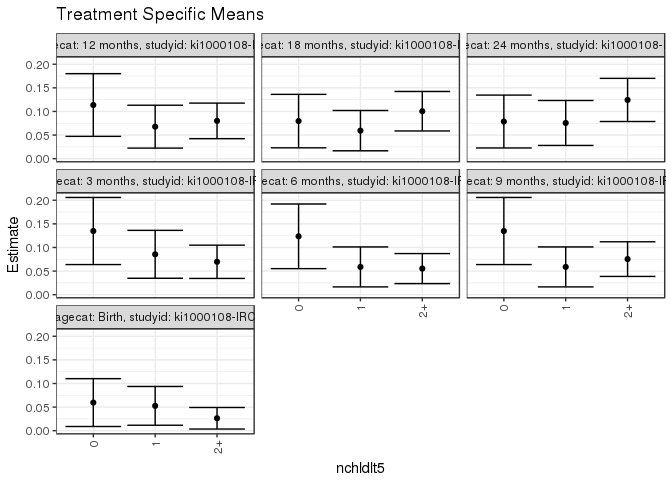

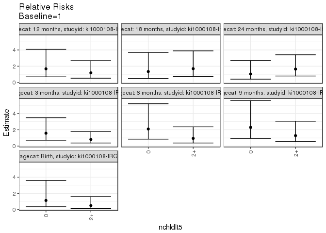

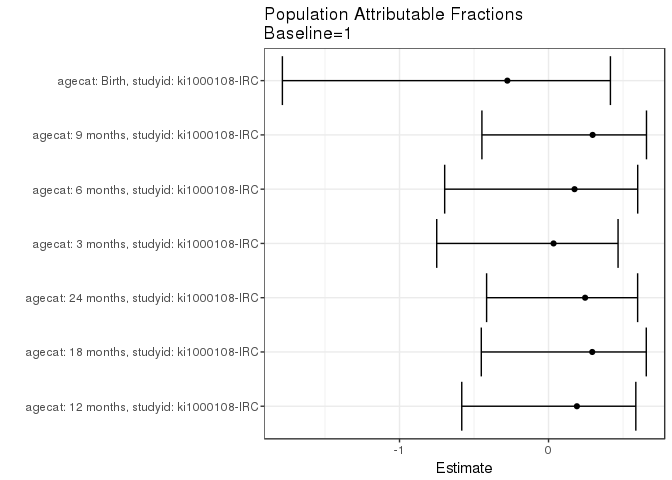

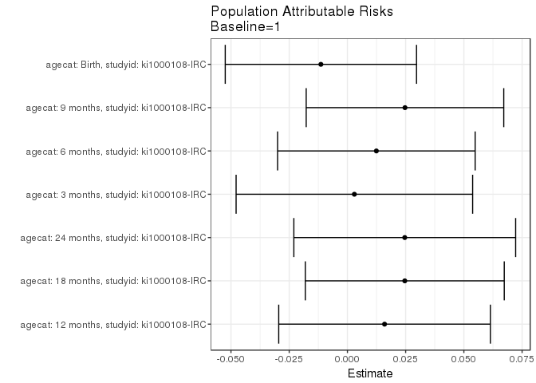

## Data Summary

| agecat | studyid | A | n | nA | nAY0 | nAY1 |
| --- | --- | --- | --- | --- | --- | --- |
| Birth | ki1000108-IRC | 1 | 388 | 114 | 108 | 6 |
| Birth | ki1000108-IRC | 0 | 388 | 84 | 79 | 5 |
| Birth | ki1000108-IRC | 2+ | 388 | 190 | 185 | 5 |
| Birth | ki1017093b-PROVIDE | 1 | 0 | 0 | 0 | 0 |
| Birth | ki1017093b-PROVIDE | 0 | 0 | 0 | 0 | 0 |
| Birth | ki1017093b-PROVIDE | 2+ | 0 | 0 | 0 | 0 |
| Birth | ki1017093c-NIH-Crypto | 1 | 27 | 8 | 8 | 0 |
| Birth | ki1017093c-NIH-Crypto | 0 | 27 | 18 | 17 | 1 |
| Birth | ki1017093c-NIH-Crypto | 2+ | 27 | 1 | 1 | 0 |
| Birth | ki1066203-TanzaniaChild2 | 1 | 0 | 0 | 0 | 0 |
| Birth | ki1066203-TanzaniaChild2 | 0 | 0 | 0 | 0 | 0 |
| Birth | ki1066203-TanzaniaChild2 | 2+ | 0 | 0 | 0 | 0 |
| Birth | ki1148112-LCNI-5 | 1 | 0 | 0 | 0 | 0 |
| Birth | ki1148112-LCNI-5 | 0 | 0 | 0 | 0 | 0 |
| Birth | ki1148112-LCNI-5 | 2+ | 0 | 0 | 0 | 0 |
| 3 months | ki1000108-IRC | 1 | 407 | 117 | 107 | 10 |
| 3 months | ki1000108-IRC | 0 | 407 | 89 | 77 | 12 |
| 3 months | ki1000108-IRC | 2+ | 407 | 201 | 187 | 14 |
| 3 months | ki1017093b-PROVIDE | 1 | 168 | 45 | 45 | 0 |
| 3 months | ki1017093b-PROVIDE | 0 | 168 | 120 | 115 | 5 |
| 3 months | ki1017093b-PROVIDE | 2+ | 168 | 3 | 3 | 0 |
| 3 months | ki1017093c-NIH-Crypto | 1 | 728 | 204 | 195 | 9 |
| 3 months | ki1017093c-NIH-Crypto | 0 | 728 | 518 | 494 | 24 |
| 3 months | ki1017093c-NIH-Crypto | 2+ | 728 | 6 | 6 | 0 |
| 3 months | ki1066203-TanzaniaChild2 | 1 | 574 | 157 | 154 | 3 |
| 3 months | ki1066203-TanzaniaChild2 | 0 | 574 | 397 | 390 | 7 |
| 3 months | ki1066203-TanzaniaChild2 | 2+ | 574 | 20 | 20 | 0 |
| 3 months | ki1148112-LCNI-5 | 1 | 0 | 0 | 0 | 0 |
| 3 months | ki1148112-LCNI-5 | 0 | 0 | 0 | 0 | 0 |
| 3 months | ki1148112-LCNI-5 | 2+ | 0 | 0 | 0 | 0 |

[output cut: 75 more lines]

## Results Table

### Parameter: TSM

| agecat | studyid | intervention_level | baseline_level | estimate | ci_lower | ci_upper |
| --- | --- | --- | --- | --- | --- | --- |
| Birth | ki1000108-IRC | 1 | NA | 0.0526316 | 0.0115886 | 0.0936745 |
| Birth | ki1000108-IRC | 0 | NA | 0.0595238 | 0.0088611 | 0.1101865 |
| Birth | ki1000108-IRC | 2+ | NA | 0.0263158 | 0.0035255 | 0.0491060 |
| 3 months | ki1000108-IRC | 1 | NA | 0.0854701 | 0.0347482 | 0.1361920 |
| 3 months | ki1000108-IRC | 0 | NA | 0.1348315 | 0.0637865 | 0.2058764 |
| 3 months | ki1000108-IRC | 2+ | NA | 0.0696517 | 0.0344168 | 0.1048866 |
| 6 months | ki1000108-IRC | 1 | NA | 0.0588235 | 0.0164963 | 0.1011508 |
| 6 months | ki1000108-IRC | 0 | NA | 0.1235955 | 0.0551349 | 0.1920561 |
| 6 months | ki1000108-IRC | 2+ | NA | 0.0552764 | 0.0234873 | 0.0870655 |
| 9 months | ki1000108-IRC | 1 | NA | 0.0588235 | 0.0164963 | 0.1011508 |
| 9 months | ki1000108-IRC | 0 | NA | 0.1348315 | 0.0637865 | 0.2058764 |
| 9 months | ki1000108-IRC | 2+ | NA | 0.0753769 | 0.0386523 | 0.1121015 |
| 12 months | ki1000108-IRC | 1 | NA | 0.0677966 | 0.0223813 | 0.1132119 |
| 12 months | ki1000108-IRC | 0 | NA | 0.1136364 | 0.0472457 | 0.1800270 |
| 12 months | ki1000108-IRC | 2+ | NA | 0.0800000 | 0.0423550 | 0.1176450 |
| 18 months | ki1000108-IRC | 1 | NA | 0.0593220 | 0.0166471 | 0.1019969 |
| 18 months | ki1000108-IRC | 0 | NA | 0.0795455 | 0.0229408 | 0.1361501 |
| 18 months | ki1000108-IRC | 2+ | NA | 0.1005025 | 0.0586765 | 0.1423286 |
| 24 months | ki1000108-IRC | 1 | NA | 0.0756303 | 0.0280664 | 0.1231941 |
| 24 months | ki1000108-IRC | 0 | NA | 0.0786517 | 0.0226565 | 0.1346469 |
| 24 months | ki1000108-IRC | 2+ | NA | 0.1243781 | 0.0786996 | 0.1700566 |

### Parameter: E(Y)

| agecat | studyid | intervention_level | baseline_level | estimate | ci_lower | ci_upper |
| --- | --- | --- | --- | --- | --- | --- |
| Birth | ki1000108-IRC | NA | NA | 0.0412371 | 0.0397608 | 0.0427134 |
| 3 months | ki1000108-IRC | NA | NA | 0.0884521 | 0.0859769 | 0.0909272 |
| 6 months | ki1000108-IRC | NA | NA | 0.0712531 | 0.0685555 | 0.0739506 |
| 9 months | ki1000108-IRC | NA | NA | 0.0835381 | 0.0808102 | 0.0862660 |
| 12 months | ki1000108-IRC | NA | NA | 0.0837438 | 0.0821303 | 0.0853574 |
| 18 months | ki1000108-IRC | NA | NA | 0.0839506 | 0.0822184 | 0.0856828 |
| 24 months | ki1000108-IRC | NA | NA | 0.1002445 | 0.0979402 | 0.1025488 |

### Parameter: RR

| agecat | studyid | intervention_level | baseline_level | estimate | ci_lower | ci_upper |
| --- | --- | --- | --- | --- | --- | --- |
| Birth | ki1000108-IRC | 0 | 1 | 1.1309524 | 0.3565442 | 3.587363 |
| Birth | ki1000108-IRC | 2+ | 1 | 0.5000000 | 0.1559014 | 1.603577 |
| 3 months | ki1000108-IRC | 0 | 1 | 1.5775281 | 0.7133718 | 3.488496 |
| 3 months | ki1000108-IRC | 2+ | 1 | 0.8149254 | 0.3736421 | 1.777378 |
| 6 months | ki1000108-IRC | 0 | 1 | 2.1011236 | 0.8473895 | 5.209789 |
| 6 months | ki1000108-IRC | 2+ | 1 | 0.9396985 | 0.3740602 | 2.360672 |
| 9 months | ki1000108-IRC | 0 | 1 | 2.2921348 | 0.9395303 | 5.592030 |
| 9 months | ki1000108-IRC | 2+ | 1 | 1.2814070 | 0.5373888 | 3.055524 |
| 12 months | ki1000108-IRC | 0 | 1 | 1.6761364 | 0.6891023 | 4.076946 |
| 12 months | ki1000108-IRC | 2+ | 1 | 1.1800000 | 0.5204196 | 2.675533 |
| 18 months | ki1000108-IRC | 0 | 1 | 1.3409091 | 0.4874723 | 3.688491 |
| 18 months | ki1000108-IRC | 2+ | 1 | 1.6941852 | 0.7379483 | 3.889518 |
| 24 months | ki1000108-IRC | 0 | 1 | 1.0399501 | 0.4022186 | 2.688827 |
| 24 months | ki1000108-IRC | 2+ | 1 | 1.6445550 | 0.7938906 | 3.406718 |

### Parameter: PAR

| agecat | studyid | intervention_level | baseline_level | estimate | ci_lower | ci_upper |
| --- | --- | --- | --- | --- | --- | --- |
| Birth | ki1000108-IRC | 1 | NA | -0.0113945 | -0.0524640 | 0.0296750 |
| 3 months | ki1000108-IRC | 1 | NA | 0.0029820 | -0.0478002 | 0.0537642 |
| 6 months | ki1000108-IRC | 1 | NA | 0.0124295 | -0.0299836 | 0.0548426 |
| 9 months | ki1000108-IRC | 1 | NA | 0.0247146 | -0.0177005 | 0.0671296 |
| 12 months | ki1000108-IRC | 1 | NA | 0.0159472 | -0.0294967 | 0.0613912 |
| 18 months | ki1000108-IRC | 1 | NA | 0.0246286 | -0.0180814 | 0.0673386 |
| 24 months | ki1000108-IRC | 1 | NA | 0.0246142 | -0.0230054 | 0.0722339 |

### Parameter: PAF

| agecat | studyid | intervention_level | baseline_level | estimate | ci_lower | ci_upper |
| --- | --- | --- | --- | --- | --- | --- |
| Birth | ki1000108-IRC | 1 | NA | -0.2763158 | -1.7860234 | 0.4153021 |
| 3 months | ki1000108-IRC | 1 | NA | 0.0337132 | -0.7503413 | 0.4665554 |
| 6 months | ki1000108-IRC | 1 | NA | 0.1744422 | -0.6970004 | 0.5983821 |
| 9 months | ki1000108-IRC | 1 | NA | 0.2958478 | -0.4470729 | 0.6573563 |
| 12 months | ki1000108-IRC | 1 | NA | 0.1904287 | -0.5823354 | 0.5857985 |
| 18 months | ki1000108-IRC | 1 | NA | 0.2933699 | -0.4512491 | 0.6559336 |
| 24 months | ki1000108-IRC | 1 | NA | 0.2455421 | -0.4156144 | 0.5979084 |